**Recurrent Neural Network**

|  | By Prof. Seungchul Lee iSystems Design Lab http://isystems.unist.ac.kr/ UNIST |
| --- | --- |

Table of Contents

# 1. Recurrent Neural Networks

## 1.1. Limitation of Feedforward Neural Nets

- 일반적인 뉴럴네트워크 (NN) 은 데이터의 순차적인 특징을 고려하지 않음
- 순차적인 데이터인 $x_1, \cdots, x_T$를 뉴럴네트워크에 반영하기 위해서는 각각의 $x$에대해 독립인 hidden state인 $h_1, \cdots, h_T$를 사용해야함

[figure not shown]

- 순차적인 데이터에 적합한 접근방식이라고는 할 수 없다.
  - e.g., sentence/paragraph/document (sequence of words), video (sequence of frames), etc.

## 1.2. Recurrent Neural Nets (RNN)

- 이전 단계의 정보를 반영하는 hidden state를 구성

[figure not shown]

- 각각의 hidden state는 다음과 같은 식으로 이루어져있음

$$ h_t = f \left( W x_t + U h_{t-1}\right) $$

$\quad \;$where $U$ is like a transition matrix and $f$ is some nonlinear function (e.g., $\tanh$).

- 각각의 hidden state $h_t$는 메모리 역할을 하여 $t$시점까지의 정보를 기억할 수 있도록 도움
- $t-1$시점의 hidden state $h_{t-1}$과 $t$시점의 hidden state $h_t$를 연결해주는 transition matrix $U$를 통해 과거의 정보를 전달

# 2. Training Neural Networks

## 2.1. RNN: Vanishing/Exploding Gradients Problem

[figure not shown]

- **Gradients Problem**
  - 시퀀스가 길어지면 hidden state가 저장하고 있는 정보가 점점 희석됨
  - 학습과정에서 반복되는 연산으로 gradient가 사라지거나 과도하게 커짐

## 2.2. Capturing Long-Range Dependencies

- 해결을 위한 기본 아이디어: 게이트(gate)를 이용하여 hidden state의 성능을 보강
  - 게이트는 정보를 **"선별하여"** 기억하거나 지우는 역할을 함

[figure not shown]

- 새로운 hidden state는 3가지 종류의 게이트로 구성되어 있음
  - input (bottom), forget (left), output (top)
  - 그림에서 열린 게이트는 'o', 닫힌 게이트는 '-'로 표기
- **LSTM**: Long Short-Term Memory 가 대표적인 방법론

# 3. Recurrent Neural Network in TensorFlow

- RNN 구조를 이용하여 숫자를 분류하는 네트워크를 구성하는 예제

## 3.1. Import Library

```python
# Import Library
import numpy as np
import matplotlib.pyplot as plt
import tensorflow as tf
import matplotlib.pyplot as plt
from six.moves import cPickle
```

## 3.2. Load Example

```python
X_all, Y_all = cPickle.load(open('./data_files/rotation_data_ohe.pkl', 'rb'))
```

- 4가지 종류의 진동데이터

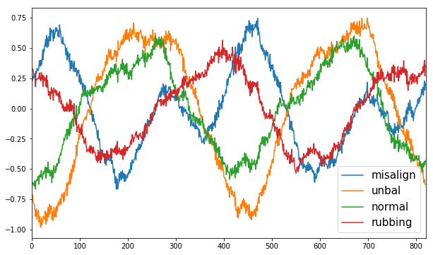

```python
data = {}
data['normal'] = X_all[np.argmax(Y_all, 1) == 0], Y_all[np.argmax(Y_all, 1) == 0]
data['misalign'] = X_all[np.argmax(Y_all, 1) == 1], Y_all[np.argmax(Y_all, 1) == 1]
data['rubbing'] = X_all[np.argmax(Y_all, 1) == 2], Y_all[np.argmax(Y_all, 1) == 2]
data['unbal'] = X_all[np.argmax(Y_all, 1) == 3], Y_all[np.argmax(Y_all, 1) == 3]

plt.figure(figsize=(10, 6))
for data_type in ['misalign', 'unbal', 'normal', 'rubbing']:
    X, y = data[data_type]
    plt.plot(X[10,:], label=data_type)
plt.legend(loc = 'lower right', fontsize = 15)
plt.xlim(0,X.shape[1])
plt.show()
```

## 3.3. Define Network Size

- Network를 구성하는데 필요한 변수 (hidden layer 수, classes 개수 등) 정의
- Tensorflow에서 LSTM RNN은 input chunk 개수와 size만 결정해주면 됨
  - n_steps: chunk의 개수
  - n_input_sequence: 각 chunk에 들어가는 data point의 수 (chunk size)

[figure not shown]

```python
total_length = 820
n_steps = 10
n_input_sequence = int(total_length//n_steps)
n_hidden = 30
n_classes = 4
```

## 3.4. Define Weights

- 학습될 변수 (파라미터) 정의

```python
weights = {
    'out' : tf.Variable(tf.random_normal([n_hidden, n_classes], stddev = 0.1))
}
biases = {
    'out' : tf.Variable(tf.random_normal([n_classes], stddev = 0.1))
}
```

## 3.5. Define Network

```python
def net(x, weights, biases, n_input, n_step, batch_size):
    x = tf.transpose(x, [1, 0, 2])
    x = tf.reshape(x, [-1, n_input])
    x = tf.split(x, n_step, 0)

    with tf.variable_scope('rnn') as scope :
        lstm_cell = tf.contrib.rnn.BasicLSTMCell(n_hidden, forget_bias=1.0, state_is_tuple=True)
        ch_tuple = lstm_cell.zero_state(batch_size, dtype=tf.float32)

        c_list = []
        h_list = []

        for input_ in x:
            try :
                h, ch_tuple = lstm_cell(input_, ch_tuple)
            except ValueError :
                scope.reuse_variables()
                h, ch_tuple = lstm_cell(input_, ch_tuple)

            c_list.append(ch_tuple[0])
            h_list.append(ch_tuple[1])

    return tf.matmul(h_list[-1], weights['out']) + biases['out']
```

## 3.6. Define Cost

- Neural Net의 output과 label $y$의 차이가 최소가 되도록 구성

```python
learning_rate = 0.5
x = tf.placeholder(tf.float32, [None, n_steps, n_input_sequence])
y = tf.placeholder(tf.float32, [None, n_classes])

Batch_size_place_holder = tf.placeholder(tf.int32)
pred = net(x, weights, biases, n_input_sequence, n_steps, Batch_size_place_holder)

cost = tf.reduce_mean(tf.square(pred - y))
optimizer = tf.train.GradientDescentOptimizer(learning_rate).minimize(cost)
```

- Tensor Graph
  - 엣지(텐서)와 노드로 이루어진 데이터 플로우 그래프 구조를 먼저 생성한 후 `tf.Session()`을 통해 수학적연산 진행

[figure not shown]

## 3.7. Define Variable

- 학습 과정에서 필요한 변수 (iteration 횟수 등) 정의

```python
n_iter = 5000
flag = 500
```

## 3.8. Optimize

- Train/valid 셋으로 나눔

```python
from sklearn.cross_validation import StratifiedKFold
skf = StratifiedKFold(np.argmax(Y_all, 1), n_folds=5)
train_indices, valid_indices = next(iter(skf))
X_train_rnn, y_train_rnn = X_all[train_indices, :], Y_all[train_indices]
X_valid_rnn, y_valid_rnn = X_all[valid_indices, :], Y_all[valid_indices]
```

```python
# Optimize
init = tf.global_variables_initializer()
sess = tf.Session()

sess.run(init)

# Training cycle
for epoch in range(n_iter):
    X_train_reshape = np.reshape(X_train_rnn, [-1, n_steps, n_input_sequence])
    sess.run(optimizer, feed_dict={x: X_train_reshape, y: y_train_rnn, Batch_size_place_holder: X_train_reshape.shape[0]})
    c = sess.run(cost, feed_dict={x: X_train_reshape,  y: y_train_rnn, Batch_size_place_holder: X_train_reshape.shape[0]})
    if epoch % flag == 0:
        print ("Iter : {}".format(epoch))
        print ("Cost : {}".format(c))
```

```
Iter : 0
Cost : 0.2241765707731247
Iter : 500
Cost : 0.055513884872198105
Iter : 1000
Cost : 0.04464704170823097
Iter : 1500
Cost : 0.04206078499555588
Iter : 2000
Cost : 0.039722051471471786
Iter : 2500
Cost : 0.03352866694331169
Iter : 3000
Cost : 0.025816822424530983
Iter : 3500
Cost : 0.020977970212697983
Iter : 4000
Cost : 0.01651313528418541
Iter : 4500
Cost : 0.013945138081908226
```

## 3.9. Test

```python
X_valid_reshape = np.reshape(X_valid_rnn, [-1, n_steps, n_input_sequence])
predict = sess.run(pred, feed_dict={x:X_valid_reshape, Batch_size_place_holder: X_valid_reshape.shape[0]})
accuracy = np.mean(np.equal(np.argmax(predict, 1), np.argmax(y_valid_rnn, 1)))
print('Accuracy = {:.4f}'.format(accuracy))
```

```
Accuracy = 0.9630
```

```python
%%javascript
$.getScript('https://kmahelona.github.io/ipython_notebook_goodies/ipython_notebook_toc.js')
```